# Data Science With an Eye Towards Sustainability Activity A2b: Univariate Visualization

# 1 Data Visualization Workflow + `ggplot`

There’s no end to the number and type of visualizations you *could* make. Thus the process can feel overwhelming. [FlowingData](http://flowingdata.com/2017/01/24/one-dataset-visualized-25-ways/) makes good recommendations for data viz workflow:

- **Ask the data questions.** Simple research questions will guide the types of visualizations that you should construct.
- **Start with the basics and work incrementally.** Before constructing complicated or multivariate or interactive graphics, start with simple visualizations. An understanding of the simple patterns provides a foundation upon which to build more advanced analyses and visualizations.Tthis incremental process works particularly well with the layered grammar of graphics in `ggplot`.
- **Focus.** Reporting a large number of visualizations can overwhelm the audience and obscure your conclusions. Instead, pick out a focused yet comprehensive set of visualizations. [Here](http://flowingdata.com/2017/01/24/one-dataset-visualized-25-ways/) is an example of one dataset visualized 25 different ways, each with a different focus and interpretation, and what can happen if you let the data ramble on without a focus.

In this course we’ll largely construct visualizations using the `ggplot` function in RStudio. Though the `ggplot` learning curve can be steep, its “grammar” is intuitive and generalizable once mastered. The `ggplot` plotting function is stored in the `ggplot2` package:

```r
library(ggplot2)
```

It is also part of the `tidyverse` package, so it gets automatically loaded when you load that package.

The best way to learn about `ggplot` is to just play around. Focus on the *patterns* and *potential* of their application. It will be helpful to have the [RStudio Data Visualization cheat sheet](https://rstudio.github.io/cheatsheets/data-visualization.pdf) handy as you complete this activity.

## 1.1 New York City Trees

[figure not shown]

The [NYC Tree Map](https://tree-map.nycgovparks.org/tree-map/) shows all of the tree manged by NYC Parks in the five boroughs of New York City. Much of the data behind these maps are from the [2015 Street Tree Census](https://data.cityofnewyork.us/Environment/2015-Street-Tree-Census-Tree-Data/uvpi-gqnh/data). The map allows you to zoom into different locations to see individual tree and features of that tree (diameter, tree type, etc.).

The entire data file from the 2015 tree census is over 220Mb, but I have made a subset with fewer variables and using only the living trees. We can load that as follows:

```r
nyc_trees<-read_csv("http://faculty.olin.edu/dshuman/DS/nyc_living_trees.csv",
col_type = list(health = col_factor(), spc_common = col_factor(), borough = col_factor()))
```

**Exercise 1.1** Before diving into any visualizations of these data, we first must understand its structure and contents.

1. What are the units of observation (cases) in this sample?
2. Use RStudio functions to:
- summarize the number of cases in `nyc_trees`
- examine the first cases of `nyc_trees`
- list out the names of all variables in `nyc_trees`
3. What are the levels of the `health` and `borough` variables?
4. Check out the [codebook/data dictionary](http://faculty.olin.edu/dshuman/DS/StreetTreeCensus2015TreesDataDictionary20161102.pdf). What does the variable `tree_dbh` capture? What are its units? Where it is measured?

*Solution*.

1. tree
2. 652173 cases, names(nyc_trees)
3. “Fair” “Good” “Poor” and “Queens” “Brooklyn” “Manhattan” “Staten Island” “Bronx”
4. Diameter at breast height (4.5 ft), unit is rounded to the nearest whole inch

**Exercise 1.2** We’ll consider *univariate* visualizations of the `health` and `tree_dbh` variables.

1. What features would we like a visualization of the *categorical* `health` variable to capture?
2. What features would we like a visualization of the *quantitative* `tree_dbh` variable to capture?

*Solution*.

1. fair, good, and poor
2. spectral value of the diameter

# 2 Categorical univariate visualization

We begin by stating a clear research question:

> Among the trees in our sample, how many fall into each of the three health classifications?

To answer the above research question, we can explore the categorical `health` variable. A table provides a simple summary of the number of trees in each classification:

```r
  table(nyc_trees$health)
```

```
##
##   Fair   Good   Poor
##  96504 528850  26818
```

Because `health` is a categorical variable, a **bar chart** provides an appropriate visualization of this table. In examining the bar chart, keep your eyes on the following.

- **variability**: Are cases evenly spread out among the categories or are some categories more common than others?
- **contextual implications**: In the context of your research, what do you learn from the bar chart? How would you describe your findings to a broad audience?

**Exercise 2.1** Try out the code below that builds up from a simple to a customized bar chart. At each step determine how each piece of code contributes to the plot.

```
    #plot 1: set up a plotting frame (a blank canvas)
    ggplot(nyc_trees, aes(x=health))

    #plot 2: what changed / how did we change it?
    ggplot(nyc_trees, aes(x=health)) +
        geom_bar()

    #plot 3: what changed / how did we change it?
    ggplot(nyc_trees, aes(x=health)) +
        geom_bar() +
        labs(x="Health Status", y="Number of Trees")

    #plot 4: what changed / how did we change it?
    ggplot(nyc_trees, aes(x=health)) +
        geom_bar(color="purple") +
        labs(x="Health Status", y="Number of Trees")

    #plot 5: what changed / how did we change it?
    ggplot(nyc_trees, aes(x=health)) +
        geom_bar(fill="purple") +
        labs(x="Health Status", y="Number of Trees")
```

*Solution*.

1. make plot
2. plot bar chart
3. add labels
4. outlines bars in purple
5. fills bars with purple

**Exercise 2.2** Summarize the visualization: what did you learn about the distribution of the `health` variable?

*Solution*. most trees are good

**Exercise 2.3** What percent of trees in the sample have a health status of `Good`?

*Solution*. 81.1%

# 3 Quantitative univariate visualization

To motivate quantitative visualizations, consider a second resarch question

> Among the trees in our sample, what’s the range of diameters? What’s the typical diameter? The largest/smallest?

We can answer the above research question by exploring the *quantitative* `tree_dbh` variable. Quantitative variables require different summary tools than categorical variables. We’ll explore two methods for graphing quantitative variables: histograms and density plots. Each of these has strengths/weaknesses in helping us visualize the distribution of observed values.

In their examination, keep your eyes on the following.

- **center**: Where’s the center of the distribution? What’s a typical value of the variable?
- **variability**: How spread out are the values? A lot or a little?
- **shape**: How are values distributed along the observed range? Is the distribution symmetric, right-skewed, left-skewed, bi-modal, or uniform (flat)?
- **outliers**: Are there any *outliers*, ie. values that are unusually large/small relative to the bulk of other values?
- **contextual implications**: Interpret these features in the context of your research. How would you describe your findings to a broad audience?

## 3.1 Histograms

Histograms are constructed by (1) dividing up the observed range of the variable into ‘bins’ of equal width; and (2) counting up the number of cases that fall into each bin.

**Exercise 3.1** Try out the code below. At each step determine how each piece of code contributes to the plot.

```
    #plot 1: set up a plotting frame
    ggplot(nyc_trees, aes(x=tree_dbh))

    #plot 2: what changed / how did we change it?
    ggplot(nyc_trees, aes(x=tree_dbh)) +
        geom_histogram()

    #plot 3: what changed / how did we change it?
    ggplot(nyc_trees, aes(x=tree_dbh)) +
        geom_histogram()+
        labs(x="Tree Diameter (inches)", y="Number of Trees")

    #plot 4: what changed / how did we change it?
    ggplot(nyc_trees, aes(x=tree_dbh)) +
        geom_histogram(color="white")+
        labs(x="Tree Diameter (inches)", y="Number of Trees")

    #plot 5: what changed / how did we change it?
    ggplot(nyc_trees, aes(x=tree_dbh)) +
        geom_histogram(fill="white")+
        labs(x="Tree Diameter (inches)", y="Number of Trees")

    #plot 6: what changed / how did we change it?
    ggplot(nyc_trees, aes(x=tree_dbh)) +
        geom_histogram(color="white",binwidth=1)+
        labs(x="Tree Diameter (inches)", y="Number of Trees")

    #plot 7: what changed / how did we change it?
    ggplot(nyc_trees, aes(x=tree_dbh)) +
        geom_histogram(color="white",binwidth=100)+
        labs(x="Tree Diameter (inches)", y="Number of Trees")

    #plot 8: what changed / how did we change it?
    ggplot(nyc_trees, aes(x=tree_dbh)) +
        geom_histogram(color="white",binwidth=5)+
        labs(x="Tree Diameter (inches)", y="Number of Trees")
```

*Solution*.

1. init plot
2. plots histogram
3. add labels
4. outline in white
5. fills it white
6. change binwidth to 1
7. change binwidth to 100
8. change binwidth to 5

**Exercise 3.2** Summarize the visualizations.

1. Describe the “goldilocks problem” in choosing a bin width that’s not too wide and not too narrow, but just right.
2. What did you learn about the distribution of the `tree_dbh` variable?
3. Why does adding `color="white"` improve the visualization?

## 3.2 Density plots

**Density plots** are essentially smooth versions of the histogram. Instead of sorting cases into discrete bins, the “density” of cases is calculated across the entire range of values. The greater the number of cases, the greater the density! The density is then scaled so that the area under the density curve **always equals 1** and the area under any fraction of the curve represents the fraction of cases that lie in that range.

**Exercise 3.3** Try the following code and assess what each line does.

```
    #plot 1: set up the plotting frame
    ggplot(nyc_trees, aes(x=tree_dbh))

    #plot 2: what changed / how did we change it?
    ggplot(nyc_trees, aes(x=tree_dbh)) +
        geom_density()

    #plot 3: what changed / how did we change it?
    ggplot(nyc_trees, aes(x=tree_dbh)) +
        geom_density() +
        labs(x="Tree Diameter (inces)")

    #plot 4: what changed / how did we change it?
    ggplot(nyc_trees, aes(x=tree_dbh)) +
        geom_density(color="red") +
        labs(x="Tree Diameter (inces)")

    #plot 5: what changed / how did we change it?
    ggplot(nyc_trees, aes(x=tree_dbh)) +
        geom_density(fill="red") +
        labs(x="Tree Diameter (inces)")
```

*Solution*.

1. init plot
2. line chart
3. x label
4. red line
5. fill red

**Exercise 3.4** The histogram and density plot both allow us to visualize the distribution of a quantitative variable. What are the pros/cons of each?

*Solution*. Histogram gives clear groupings, where density gives more granularity for the whole dataset.

# 4 Additional exercises

No class will teach you everything you need to know about RStudio or programming in general. Thus, being able to find help online is an important skill. To this end, some of the following exercises will require a little Googling and/or use of the visualization cheat sheet.

**Exercise 4.1**

1. Make a bar chart of the number of trees in each borough. Make sure to label your axes.
2. Sort the bars in descending order of the number of trees (so that the borough with the most trees is farthest left on the x-axis and the borough with the fewest trees is farthest right on the x-axis).
3. Flip the bar chart so that each bar is horizontal and the x-axis shows the number of trees [hint: this should be just one extra line on top of your previous code].

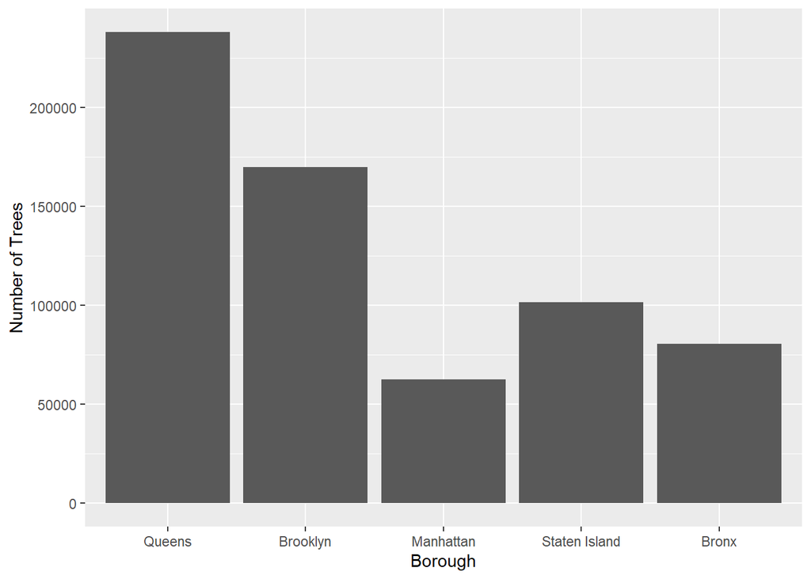

```r
ggplot(nyc_trees, aes(x=borough)) + geom_bar() + labs(x="Borough", y="Number of Trees")
```

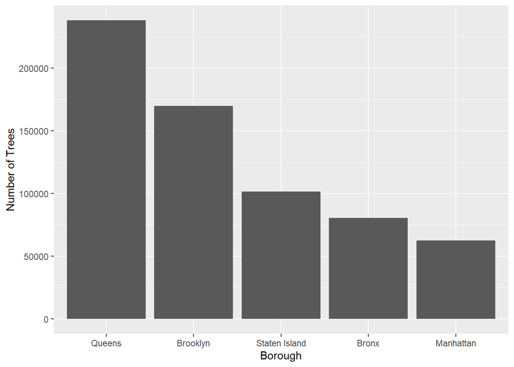

```r
ggplot(nyc_trees, aes(x=fct_infreq(borough))) + geom_bar() + labs(x="Borough", y="Number of Trees")
```

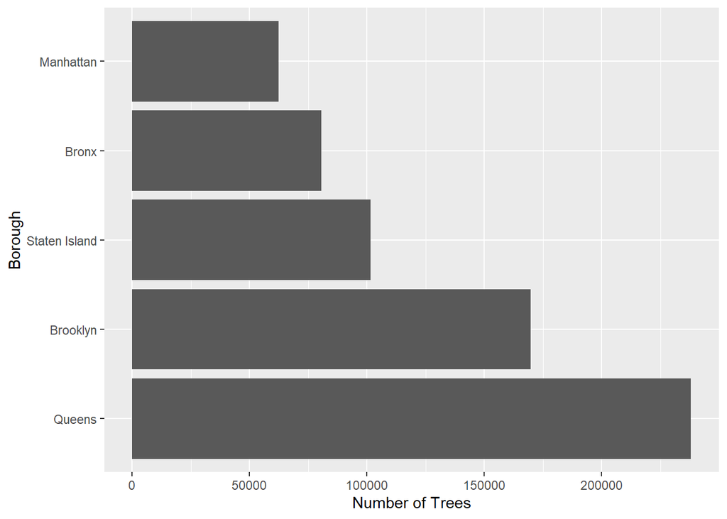

```r
ggplot(nyc_trees, aes(x=fct_infreq(borough))) + geom_bar() + labs(x="Borough", y="Number of Trees") + coord_flip()
```

**Exercise 4.2** Make a single visualization that incorporates the following modifications to your density plot of tree diameter from above.

- Add a title or caption
- Add *transparency* to the fill color
- Calculate the mean (ie. average) diameter and median diameter:

```r
  mean(nyc_trees$tree_dbh)
  median(nyc_trees$tree_dbh)
```

- Add two vertical lines to your plot: one representing the mean and the other representing the median. Use two different colors and/or line types
- Change the limits of the x-axis to range from 0-80 inches

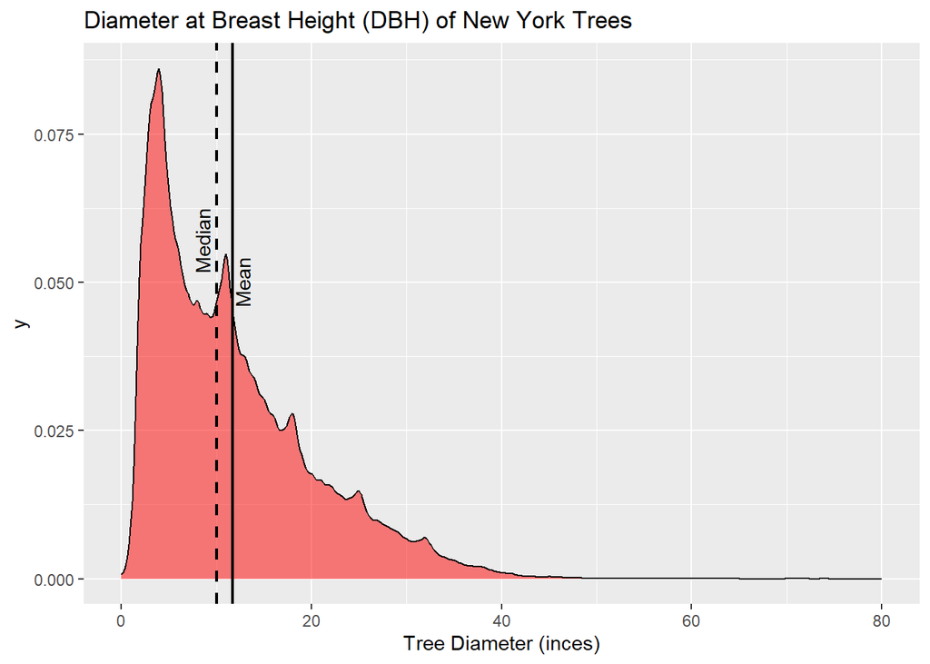

```r
ggplot(nyc_trees, aes(x=tree_dbh)) +
  geom_density(fill="red", alpha=0.5) +
  geom_vline(aes(xintercept=mean(nyc_trees$tree_dbh)), linewidth=0.8) +
  geom_vline(aes(xintercept=median(nyc_trees$tree_dbh)), linewidth=0.8, linetype="dashed") +
  xlim(0,80) +
  labs(x="Tree Diameter (inces)", title="Diameter at Breast Height (DBH) of New York Trees") +
  annotate("text", x=mean(nyc_trees$tree_dbh)+1, y=0.05, label="Mean", angle=90) +
  annotate("text", x=median(nyc_trees$tree_dbh)-1.5, y=0.057, label="Median", angle=90)
```

**Exercise 4.3** Explain the output of the following code, relating it to your visualization from the previous exercise:

```r
summary(nyc_trees$tree_dbh)
```

```
##    Min. 1st Qu.  Median    Mean 3rd Qu.    Max.
##    0.00    5.00   10.00   11.71   16.00  425.00
```

*Solution*.

- The minimum dbh is 0 inches (likely an input error)
- A quarter of the data is below 5 inches
- The median dbh is 10 inches
- The mean dbh is 11.71 inches
- Three quarters of the data is below 16 inches
- The maximum dbh is 425 inches

**Exercise 4.4** So far, all of our visualizations have been *univariate*; i.e., focusing on a single variable. We can start to answer more interesting questions with *bivariate* and *multivariate* tables and visualizations.

For example, let’s contemplate the question, “how does the distribution of tree health status vary across the boroughs?”

Make a two-way table that shows the total number of trees by borough (row) and health status (column). As a check, there should be 194,008 trees in Queens with a status of Good.

Next class, we’ll learn to make bivariate visualizations to answer questions like this one, as well as:

- “How do tree diameter/tree health vary by tree type?”
- “Which types of trees are more commonly found in which parts of the city?”
- …

```r
table(nyc_trees$borough, nyc_trees$health)
```

```
##
##                   Fair   Good   Poor
##   Queens         34549 194008   9417
##   Brooklyn       25073 138212   6459
##   Manhattan      11460  47358   3609
##   Staten Island  14535  82669   4238
##   Bronx          10887  66603   3095
```